# NHANES Data Analysis

Elan Y. Ding  
Department of Mathematics  
Clemson University  
Greenville Health System  
yirending@gmail.com

## 1: Collecting NHANES data from 2003-2016

### 1.1 Basic Information

#### Data source:

https://wwwn.cdc.gov/nchs/nhanes/Default.aspx

#### File names:

DEMO (Demographics)  
HDL (HDL levels)  
TRIG (Triglycerides and LDL levels)  
TCHOL (Total cholesterol levels)

#### Features:

SEQN - Respondent sequence number  
LBDHDD - Direct HDL-Cholesterol (mg/dL)  
LBXHDD - Direct HDL-Cholesterol (mg/dL) (2003 only)  
LBDLDL - LDL-cholesterol (mg/dL)  
LBXTR - Triglyceride (mg/dL)  
LBXSTR - Triglyceride (mg/dL) (2015 only)  
LBXTC - Total cholesterol (mg/dL)  
RIAGENDR - Gender  
RIDAGEYR - Age at Screening Adjudicated - Recode  
RIDRETH1 - Race/Ethnicity - Recode

```
1 - Mexican American
2 - Other Hispanic
3 - Non-Hispanic White
4 - Non-Hispanic Black
5 - Other Race - Including Multi-Racial
```

INDFMIN2 - Annual Family Income

```
1 - 0 to 4,999
2 - 5,000 to 9,999
3 - 10,000 to 14,999
4 - 15,000 to 19,999
5 - 20,000 to 24,999
6 - 25,000 to 34,999
7 - 35,000 to 44,999
8 - 45,000 to 54,999
9 - 55,000 to 64,999
10 - 65,000 to 74,999
11 - 75,000 and Over
12 - Over 20,000
13 - Under 20,000
14 - 75,000 to 99,999
15 - 100,000 and Over
77 - Refused
99 - Don't know
```

INDFMINC - Annual Family Income (2003 2005 Only)

```
1 - 0 to 4,999
2 - 5,000 to 9,999
3 - 10,000 to 14,999
4 - 15,000 to 19,999
5 - 20,000 to 24,999
6 - 25,000 to 34,999
7 - 35,000 to 44,999
8 - 45,000 to 54,999
9 - 55,000 to 64,999
10 - 65,000 to 74,999
11 - 75,000 and Over
12 - Over 20,000
13 - Under 20,000
77 - Refused
99 - Don't know
```

DMDEDUC3 - Education Level - Children/Youth 6-19

```
13 - High School Graduate
14 - GED or Equivalent
15 - More than high school
```

DMDEDUC2 - Education Level - Adults 20+

```
3 - High School Grad/GED or Equivalent
4 - Some College or AA degree
5 - College Graduate or above
```

### 1.2 Data Collection

```python
import numpy as np
import pandas as pd
import matplotlib.pyplot as plt
import seaborn as sns
%matplotlib inline
```

```python
# Demographics

demo03 = pd.read_csv('DEMO_C_03.csv')
demo05 = pd.read_csv('DEMO_D_05.csv')
demo07 = pd.read_csv('DEMO_E_07.csv')
demo09 = pd.read_csv('DEMO_F_09.csv')
demo11 = pd.read_csv('DEMO_G_11.csv')
demo13 = pd.read_csv('DEMO_H_13.csv')
demo15 = pd.read_csv('DEMO_I_15.csv')

# HDL

hdl03 = pd.read_csv('L13_C.csv') # also contains total cholesterol in 2003
hdl05 = pd.read_csv('HDL_D_05.csv')
hdl07 = pd.read_csv('HDL_E_07.csv')
hdl09 = pd.read_csv('HDL_F_09.csv')
hdl11 = pd.read_csv('HDL_G_11.csv')
hdl13 = pd.read_csv('HDL_H_13.csv')
hdl15 = pd.read_csv('HDL_I_15.csv')

# Triglyceride

trig03 = pd.read_csv('L13AM_C.csv')
trig05 = pd.read_csv('TRIGLY_D_05.csv')
trig07 = pd.read_csv('TRIGLY_E_07.csv')
trig09 = pd.read_csv('TRIGLY_F_09.csv')
trig11 = pd.read_csv('TRIGLY_G_11.csv')
trig13 = pd.read_csv('TRIGLY_H_13.csv')
trig15 = pd.read_csv('BIOPRO_I.csv') # triglyceride in 2015

# Total Cholesterol (2003 data is included in hdl03)

tchol05 = pd.read_csv('TCHOL_D_05.csv')
tchol07 = pd.read_csv('TCHOL_E_07.csv')
tchol09 = pd.read_csv('TCHOL_F_09.csv')
tchol11 = pd.read_csv('TCHOL_G_11.csv')
tchol13 = pd.read_csv('TCHOL_H_13.csv')
tchol15 = pd.read_csv('TCHOL_I_15.csv')
```

Since the NHANES 2015 dataset does not have the adjusted weights for Triglyceride levels, we use MEC weights from the DEMO_I_15 file, adjusted by a factor 4/5. (Reason will be shown below.) See https://wwwn.cdc.gov/Nchs/Nhanes/2015-2016/BIOPRO_I.htm

```python
trig15['WTSAF2YR'] = demo15['WTMEC2YR']*4/5
```

```python
# Demographics

demo = pd.concat([demo03, demo05, demo07, demo09, demo11, demo13, demo15])
demo = demo[['SEQN','RIAGENDR', 'RIDAGEYR', 'RIDRETH1','DMDEDUC3', 'DMDEDUC2',
             'INDFMINC','INDFMIN2','WTINT2YR','WTMEC2YR']]
demo.columns = ['Index', 'Gender', 'Age', 'Ethnicity', 'Education 6-19', 'Education 20+',
              'Income 2003-05', 'Income 2007+', 'Weight Int', 'Weight MEC']
demo.set_index('Index', inplace = True)

# Combine columns

demo['Education 6-19'] = demo['Education 6-19'].fillna(0.0)
demo['Education 20+'] = demo['Education 20+'].fillna(0.0)
demo['Income 2003-05'] = demo['Income 2003-05'].fillna(0.0)
demo['Income 2007+'] = demo['Income 2007+'].fillna(0.0)
demo['Education'] = demo['Education 6-19'] + demo['Education 20+']
demo['Income'] = demo['Income 2003-05'] + demo['Income 2007+']
demo.drop(['Education 6-19', 'Education 20+', 'Income 2003-05', 'Income 2007+'], axis=1, inplace = True)
```

```python
# HDL

hdl = pd.concat([hdl03, hdl05, hdl07, hdl09, hdl11, hdl13, hdl15])
hdl = hdl[['SEQN', 'LBDHDD', 'LBXHDD']]
hdl.columns = ['Index', 'HDL1', 'HDL2']
hdl.set_index('Index', inplace = True)

# Combine columns

hdl['HDL1'] = hdl['HDL1'].fillna(0.0)
hdl['HDL2'] = hdl['HDL2'].fillna(0.0)
hdl['HDL'] = hdl['HDL1'] + hdl['HDL2']
hdl.drop(['HDL1', 'HDL2'], axis=1, inplace=True)
```

```python
# Tryglyceride

trig = pd.concat([trig03, trig05, trig07, trig09, trig11, trig13, trig15])
trig = trig[['SEQN', 'WTSAF2YR', 'LBXTR', 'LBXSTR']]
trig.columns = ['Index', 'Weight Fast', 'Triglyceride', 'Triglyceride2']
trig.set_index('Index', inplace = True)

# Combine columns

trig['Triglyceride'] = trig['Triglyceride'].fillna(0.0)
trig['Triglyceride2'] = trig['Triglyceride2'].fillna(0.0)
trig['Triglyceride'] = trig['Triglyceride'] + trig['Triglyceride2']
trig.drop(['Triglyceride2'], axis=1, inplace=True)
```

```python
# Total Cholesterol

tchol = pd.concat([hdl03, tchol05, tchol07, tchol09, tchol11, tchol13, tchol15])
tchol = tchol[['SEQN', 'LBXTC']]
tchol.columns = ['Index', 'Total Chol']
tchol.set_index('Index', inplace = True)
```

```python
# Combine all into one data frame

from functools import reduce

dfs = [demo, hdl, trig, tchol]
df = reduce(lambda left,right: left.join(right), dfs)
df = df[['Age', 'Gender', 'Ethnicity', 'Education', 'Income', 'HDL',
         'Triglyceride', 'Total Chol', 'Weight Int', 'Weight MEC', 'Weight Fast']]
df.head()
```

| Index | Age | Gender | Ethnicity | Education | Income | HDL | Triglyceride | Total Chol | Weight Int | Weight MEC | Weight Fast |
| --- | --- | --- | --- | --- | --- | --- | --- | --- | --- | --- | --- |
| 21005.0 | 19.0 | 1.0 | 4.0 | 11.0 | 6.0 | 44.0 | 102.0 | 189.0 | 5512.320949 | 5824.782465 | 14084.2 |
| 21006.0 | 16.0 | 2.0 | 4.0 | 11.0 | 6.0 | 53.0 | 71.0 | 159.0 | 5422.140453 | 5564.039715 | 13081.0 |
| 21007.0 | 14.0 | 2.0 | 3.0 | 8.0 | 6.0 | 69.0 | NaN | 212.0 | 39764.177412 | 40591.066325 | NaN |
| 21008.0 | 17.0 | 1.0 | 4.0 | 10.0 | 7.0 | 66.0 | NaN | 175.0 | 5599.499351 | 5696.750596 | NaN |
| 21009.0 | 55.0 | 1.0 | 3.0 | 3.0 | 8.0 | 37.0 | NaN | 254.0 | 97593.678977 | 97731.727244 | NaN |

```python
df['Age'].describe()
```

```
count    71058.000000
mean        31.198204
std         24.850422
min          0.000000
25%          9.000000
50%         25.000000
75%         51.750000
max         85.000000
Name: Age, dtype: float64
```

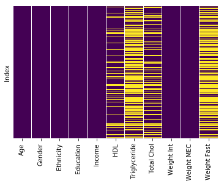

```python
# Check for missing values (Yellow bar indicades missing value)

sns.heatmap(df.isnull(), yticklabels = False, cbar=False, cmap = 'viridis')
```

## 2 Designing sample weights

According to NHANES guidelines, there are three types of weights, with different uses.

```
WTINT2YR - (Weight Int) This should be used for analyzing interview data in a 2-year cycle , such as demographic information.

WTMEC2YR - (Weight MEC) This weight should be used for analyzing MEC examinination data in a 2-year cycle, such as HDL levels.

WTSAF2YR - (Weight Fast) This subsample weight should be used for analyzing Triglyceride levels.
```

First we look at the raw weights, and note that they sum to the size of U.S. population. For example, in 2005, the raw weights sum to roughly 290 million, which is roughly the U.S. population in 2005.

```python
demo05['WTINT2YR'].sum()
```

```
291616891.83997804
```

Note that the fasting subsample weight sums to less than US population. (This is more than 4/5 of the U.S. population. This is the reason we adjusted the MEC weight by 4/5 earlier.)

```python
trig05['WTSAF2YR'].sum()
```

```
243600773.577
```

### 2.1 Combining survey cycles

The adopt the following methodology

https://www.cdc.gov/nchs/tutorials/nhanes/SurveyDesign/Weighting/Task2.htm

to change the survey weigths after combining the 7 2-year cycles (2003-2004, 2005-2006, 2007-2008, 2009-2010, 2011-2012 2013-2014, 2015-2016). Let $\{w_1,w_2,...,w_n\}$ be the original weights of the combined dataset. The adjusted weights are defined by $$ w'_i = \frac{1}{7} w_i, \,\, i=1,...,n $$

```python
df['Weight Int'] = df['Weight Int']/7
df['Weight MEC'] = df['Weight MEC']/7
df['Weight Fast'] = df['Weight Fast']/7
df.head()
```

| Index | Age | Gender | Ethnicity | Education | Income | HDL | Triglyceride | Total Chol | Weight Int | Weight MEC | Weight Fast |
| --- | --- | --- | --- | --- | --- | --- | --- | --- | --- | --- | --- |
| 21005.0 | 19.0 | 1.0 | 4.0 | 11.0 | 6.0 | 44.0 | 102.0 | 189.0 | 787.474421 | 832.111781 | 2012.028571 |
| 21006.0 | 16.0 | 2.0 | 4.0 | 11.0 | 6.0 | 53.0 | 71.0 | 159.0 | 774.591493 | 794.862816 | 1868.714286 |
| 21007.0 | 14.0 | 2.0 | 3.0 | 8.0 | 6.0 | 69.0 | NaN | 212.0 | 5680.596773 | 5798.723761 | NaN |
| 21008.0 | 17.0 | 1.0 | 4.0 | 10.0 | 7.0 | 66.0 | NaN | 175.0 | 799.928479 | 813.821514 | NaN |
| 21009.0 | 55.0 | 1.0 | 3.0 | 3.0 | 8.0 | 37.0 | NaN | 254.0 | 13941.954140 | 13961.675321 | NaN |

### 2.2 Normalizing weights

Let $\{S_1,S_2,...,S_n\}$ be the original sample of size $n$, associated with raw weights $\{w_1,w_2,...,w_n\}$.

For each sampled unit $S_i$, define the normalized sample weight as $$ w'_i = \frac{w_i}{\frac{1}{n} \sum_{i=1}^n w_i}. $$

In this case the sum of the normalized weights sum to the sample size: $$ \sum_{i=1}^n w'_i = \frac{\sum_{i=1}^n w_i}{\frac{1}{n} \sum_{j=1}^n w_j} = n $$

```python
df['Weight Int'] = df['Weight Int']/df['Weight Int'].mean()
df['Weight MEC'] = df['Weight MEC']/df['Weight MEC'].mean()
df['Weight Fast'] = df['Weight Fast']/df['Weight Fast'].mean()
df.head()
```

| Index | Age | Gender | Ethnicity | Education | Income | HDL | Triglyceride | Total Chol | Weight Int | Weight MEC | Weight Fast |
| --- | --- | --- | --- | --- | --- | --- | --- | --- | --- | --- | --- |
| 21005.0 | 19.0 | 1.0 | 4.0 | 11.0 | 6.0 | 44.0 | 102.0 | 189.0 | 0.185532 | 0.196049 | 0.227178 |
| 21006.0 | 16.0 | 2.0 | 4.0 | 11.0 | 6.0 | 53.0 | 71.0 | 159.0 | 0.182497 | 0.187273 | 0.210996 |
| 21007.0 | 14.0 | 2.0 | 3.0 | 8.0 | 6.0 | 69.0 | NaN | 212.0 | 1.338371 | 1.366202 | NaN |
| 21008.0 | 17.0 | 1.0 | 4.0 | 10.0 | 7.0 | 66.0 | NaN | 175.0 | 0.188466 | 0.191740 | NaN |
| 21009.0 | 55.0 | 1.0 | 3.0 | 3.0 | 8.0 | 37.0 | NaN | 254.0 | 3.284780 | 3.289426 | NaN |

```python
df['Weight MEC'].sum()
```

```
71058.0
```

### 2.3 Sub-sample Weight Adjustment

Let $\{S_1,S_2,...,S_n\}$ be a sample of size $n$, with normalized weights $\{w_1, w_2,...,w_n\}$, such that $\sum_{i=1}^n w_i = n$.

Let $\{U_1,U_2,...,U_k\}, k\leq n$ be a subsample with weights $\{w'_1, w'_2,...,w'_n\}$, which are defined as $$ w'_i = \frac{w_i}{\frac{1}{k}\sum_{j=1}^k w_j} $$ Note that the sum of the adjusted sample weights sum to $k$: $$ \sum_{i=1}^k w'_i = \frac{\sum_{i=1}^k w_i}{\frac{1}{k}\sum_{j=1}^k w_j} = k. $$ This method will be applied each time we take a sub-sample of the 71058 individuals in our combined dataset.

#### 2.3.1 HDL Subsample

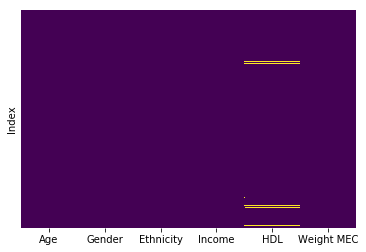

```python
# Taking a subsample of college students age 18-24
df_hdl = df[(df['Age'] > 17) & (df['Age'] < 25) & (df['Education'].isin([3.0, 4.0, 5.0, 13.0, 14.0, 15.0]))
           ][['Age', 'Gender', 'Ethnicity', 'Income', 'HDL', 'Weight MEC']].copy()

# Check for missing values
sns.heatmap(df_hdl.isnull(), yticklabels = False, cbar=False, cmap = 'viridis')
```

```python
# Fill in the missing value by taking a sample average:
df_hdl['HDL'].fillna(df_hdl['HDL'].mean(), inplace=True)

# Adjusting for sub-sample weights
df_hdl['Weight MEC'] = df_hdl['Weight MEC']/df_hdl['Weight MEC'].mean()

# Note that the updated weights sum to the sub-sample size:
df_hdl['Weight MEC'].sum()
```

```
4370.0
```

#### 2.3.2 Triglyceride Subsample

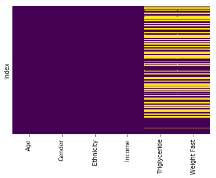

```python
# Taking a subsample of college students age 18-24
df_trig = df[(df['Age'] > 17) & (df['Age'] < 25) & (df['Education'].isin([3.0, 4.0, 5.0, 13.0, 14.0, 15.0]))
            ][['Age', 'Gender', 'Ethnicity', 'Income', 'Triglyceride', 'Weight Fast']].copy()

# Check for missing values
sns.heatmap(df_trig.isnull(), yticklabels = False, cbar=False, cmap = 'viridis')
```

```python
# Note that the missing values occur together, so we drop them:
df_trig = df_trig.dropna()

# Adjusting for subsample weights
df_trig['Weight Fast'] = df_trig['Weight Fast']/df_trig['Weight Fast'].mean()

# Note that the updated weights sum to the sub-sample size:
df_trig['Weight Fast'].sum()
```

```
2338.0
```

#### 2.3.3 Total Cholesterol Subsample

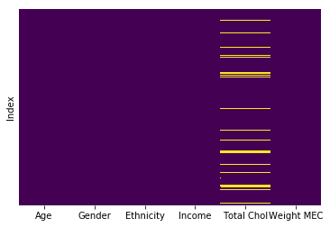

```python
# Taking a subsample of college students age 18-24
df_tchol = df[(df['Age'] > 17) & (df['Age'] < 25) & (df['Education'].isin([3.0, 4.0, 5.0, 13.0, 14.0, 15.0]))
            ][['Age', 'Gender', 'Ethnicity', 'Income', 'Total Chol', 'Weight MEC']].copy()

# Check for missing values
sns.heatmap(df_tchol.isnull(), yticklabels = False, cbar=False, cmap = 'viridis')
```

```python
# Fill in the missing value by taking a sample average:
df_tchol['Total Chol'] = df_tchol['Total Chol'].fillna(df_tchol['Total Chol'].mean())

# Adjusting for subsample weights
df_tchol['Weight MEC'] = df_tchol['Weight MEC']/df_tchol['Weight MEC'].mean()

# Note that the updated weights sum to the sub-sample size:
df_tchol['Weight MEC'].sum()
```

```
4370.0
```

## 3 Data Analysis

### 3.1 Remapping data

First we divide "Income" into three groups:

```
1. "low" - if Family Income < 20000
2. "mid" - if 20000 < Family Income < 75000
3. "high" - if Family Income > 75000
```

We also specify the ethnicity values according to NHANES guide:

```
1. Mexican
2. Hispanic
3. White
4. Black
5. Other
```

Fianlly, we apply the map for gender:

```
1. Male
2. Female
```

```python
# Mapping income and ethnicity

def income_map( x ):
    if x in [1.0, 2.0, 3.0, 4.0, 13.0]:
        return 'low'
    elif x in [5.0, 6.0, 7.0, 8.0, 9.0, 10.0, 12.0]:
        return 'mid'
    elif x in [11.0, 14.0, 15.0]:
        return 'high'
    else:
        return np.nan

ethnicity_map = {1:'Mexican', 2:'Hispanic', 3:'White', 4:'Black', 5:'Other'}
gender_map = {1.0:'Male', 2.0: 'Female'}

df_hdl['Income'] = df_hdl['Income'].apply(income_map)
df_trig['Income'] = df_trig['Income'].apply(income_map)
df_tchol['Income'] = df_tchol['Income'].apply(income_map)

df_hdl['Gender'] = df_hdl['Gender'].map(gender_map)
df_trig['Gender'] = df_trig['Gender'].map(gender_map)
df_tchol['Gender'] = df_tchol['Gender'].map(gender_map)

df_hdl['Ethnicity'] = df_hdl['Ethnicity'].map(ethnicity_map)
df_trig['Ethnicity'] = df_trig['Ethnicity'].map(ethnicity_map)
df_tchol['Ethnicity'] = df_tchol['Ethnicity'].map(ethnicity_map)
```

### 3.2 Mathematical Background

#### 3.2.1 Calculating Weighted Sample Variance

Let $X_1, X_2,..., X_n$ be iid samples with sample weights $w_1,w_2,...,w_n$. Then define $$ p_i = \frac{w_i}{\sum_{i=1}^n w_i}, \quad \text{ such that } \sum_{i=1}^n p_i = 1 $$

The weighted sample mean is given by $$ \bar{X} = \sum_{i=1}^n X_i p_i $$ The biased weighted sample variance is given by $$ S_{\text{bias}}^2 = \sum_{i=1}^n (X_i - \bar{X})^2 p_i = \sum_{i=1}^n X_i^2 p_i - \bar{X}^2 $$

#### 3.2.2 Adjusting for weighted sample variance biase

To adjust for the biase in $S_{\text{bias}}^2$, we take the expected value: $$ \begin{aligned} E(S_{\text{bias}}^2) &= E\left[\sum_{i=1}^n(X_i - \mu)^2 p_i - 2(\bar{x}-\mu)\sum_{i=1}^n(X_i - \mu)p_i + (\bar{x}-\mu)^2\sum_{i=1}^n p_i \right] \\ &=E\left[\sum_{i=1}^n(X_i-\mu)^2p_i - 2(\bar{x}-\mu)\left(\sum_{i=1}^n(x_i-\bar{x})p_i + \sum_{i=1}^n(\bar{x}-\mu)p_i\right) + (\bar{x}-\mu)^2 \right] \\ &=E\left[ \sum_{i=1}^n(X_i-\mu)^2 p_i - 2(\bar{x}-\mu)^2 + (\bar{x}-\mu)^2\right] \\ &=E\left[\sum_{i=1}^n (X_i-\mu)^2 p_i - (\bar{x}-\mu)^2\right] \\ &=E\left[\sum_{i=1}^n (X_i-\mu)^2 p_i\right] - E\left[(\bar{x}-\mu)^2\right] \\ &=\sum_{i=1}^np_i E\left[(X_i-\mu)^2\right] - \text{Var}(\bar{x}) + \left[E(\bar{x}-\mu)\right]^2 \\ &= \sigma^2 - \text{Var}\left[\sum_{i=1}^n X_i p_i\right] \\ &= \sigma^2\left(1-\sum_{i=1}^np_i^2\right) \end{aligned} $$

Hence, we define the unbiased weighted sample variance as $$ S^2 = \frac{1}{1-\sum_{i=1}^n p_i^2} \sum_{i=1}^n(X_i-\bar{X})^2 p_i = \left(1- \frac{\sum_{i=1}^n w_i^2}{\left(\sum_{i=1}^n w_i\right)^2}\right)^{-1}\left(\sum_{i=1}^n X_i^2 p_i - \bar{X}^2\right) $$

If we are using normalized weights, then $\sum_{i=1}^n w_i = n$, so that $$ S^2 = \left(1- \frac{1}{n^2} \sum_{i=1}^n w_i^2\right)^{-1}\left(\sum_{i=1}^n X_i^2 p_i - \bar{X}^2\right) $$

```python
# Define a function that retuns (a, b, c) where a is the point estimate of the mean,
# and (b, c) is the 100*(1-alpha)% confidence interval

import scipy.stats as st

def weighted_estimate( values, weights, alpha ):

    mean = np.average( values, weights = weights )
    S = np.sqrt((np.average( values**2, weights = weights ) - mean**2 )/( 1-np.sum(weights**2)/len(weights)**2) )

    return (mean, mean - st.t.ppf(1-alpha/2, len(weights)-1)*S/np.sqrt(len(weights)),
            mean + st.t.ppf(1-alpha/2, len(weights)-1)*S/np.sqrt(len(weights)) )
```

### 3.3 HDL Analysis

```python
df_hdl.head()
```

| Index | Age | Gender | Ethnicity | Income | HDL | Weight MEC |
| --- | --- | --- | --- | --- | --- | --- |
| 21097.0 | 23.0 | Female | Black | mid | 45.0 | 0.775859 |
| 21107.0 | 20.0 | Male | White | mid | 29.0 | 1.860274 |
| 21130.0 | 20.0 | Female | Black | high | 53.0 | 0.806247 |
| 21171.0 | 20.0 | Female | Black | low | 58.0 | 0.894561 |
| 21175.0 | 18.0 | Female | Black | low | 53.0 | 0.184017 |

```python
df_hdl['HDL'].count()
```

```
4370
```

#### 3.3.1 Gender

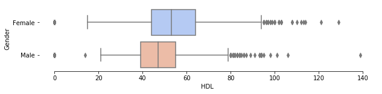

```python
f, ax = plt.subplots(figsize=(10, 2))
sns.boxplot(y='Gender', x='HDL', data=df_hdl, palette='coolwarm')
sns.despine(trim=True, left=True)
```

```python
df_hdl.groupby('Gender')['HDL'].describe()
```

| Gender | count | mean | std | min | 25% | 50% | 75% | max |
| --- | --- | --- | --- | --- | --- | --- | --- | --- |
| Female | 2304.0 | 51.768137 | 20.818749 | 0.0 | 44.0 | 53.0 | 64.0 | 129.0 |
| Male | 2066.0 | 44.927618 | 18.023397 | 0.0 | 39.0 | 47.0 | 55.0 | 139.0 |

```python
hdl_values_male = np.array(df_hdl[df_hdl['Gender'] == 'Male']['HDL'])
hdl_weights_male = np.array(df_hdl[df_hdl['Gender'] == 'Male']['Weight MEC'] /
                           df_hdl[df_hdl['Gender'] == 'Male']['Weight MEC'].mean())

hdl_values_female = np.array(df_hdl[df_hdl['Gender'] == 'Female']['HDL'])
hdl_weights_female = np.array(df_hdl[df_hdl['Gender'] == 'Female']['Weight MEC'] /
                             df_hdl[df_hdl['Gender'] == 'Female']['Weight MEC'].mean())
```

```python
weighted_estimate(hdl_values_female, hdl_weights_female, 0.05)
```

```
(51.61787802850586, 50.751461153280545, 52.48429490373117)
```

```python
weighted_estimate(hdl_values_male, hdl_weights_male, 0.05)
```

```
(44.104081667381, 43.32438701352597, 44.883776321236034)
```

#### 3.3.2 Income

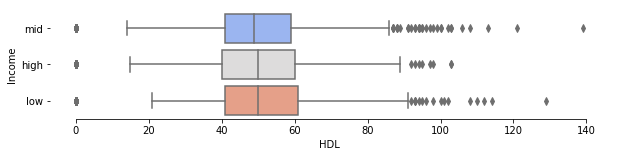

```python
f, ax = plt.subplots(figsize=(10, 2))
sns.boxplot(y='Income', x='HDL', data=df_hdl, palette='coolwarm')
sns.despine(trim=True, left=True)
```

```python
df_hdl.groupby('Income')['HDL'].describe()
```

| Income | count | mean | std | min | 25% | 50% | 75% | max |
| --- | --- | --- | --- | --- | --- | --- | --- | --- |
| high | 745.0 | 48.325749 | 20.177194 | 0.0 | 40.0 | 50.0 | 60.0 | 103.0 |
| low | 1521.0 | 49.046533 | 20.035971 | 0.0 | 41.0 | 50.0 | 61.0 | 129.0 |
| mid | 1902.0 | 48.346778 | 19.469684 | 0.0 | 41.0 | 49.0 | 59.0 | 139.0 |

```python
hdl_values_low = np.array(df_hdl[df_hdl['Income'] == 'low']['HDL'])
hdl_weights_low = np.array(df_hdl[df_hdl['Income'] == 'low']['Weight MEC'] /
                          df_hdl[df_hdl['Income'] == 'low']['Weight MEC'].mean())

hdl_values_mid = np.array(df_hdl[df_hdl['Income'] == 'mid']['HDL'])
hdl_weights_mid = np.array(df_hdl[df_hdl['Income'] == 'mid']['Weight MEC'] /
                          df_hdl[df_hdl['Income'] == 'mid']['Weight MEC'].mean())

hdl_values_high = np.array(df_hdl[df_hdl['Income'] == 'high']['HDL'])
hdl_weights_high = np.array(df_hdl[df_hdl['Income'] == 'high']['Weight MEC'] /
                           df_hdl[df_hdl['Income'] == 'high']['Weight MEC'].mean())
```

```python
weighted_estimate(hdl_values_low, hdl_weights_low, 0.05)
```

```
(48.314575234559996, 47.284023264745315, 49.34512720437468)
```

```python
weighted_estimate(hdl_values_mid, hdl_weights_mid, 0.05)
```

```
(48.08472537260012, 47.20433232307273, 48.96511842212751)
```

```python
weighted_estimate(hdl_values_high, hdl_weights_high, 0.05)
```

```
(47.03794813680216, 45.592474225654044, 48.48342204795027)
```

#### 3.3.3 Ethnicity

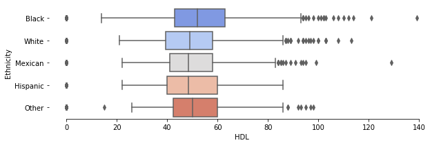

```python
f, ax = plt.subplots(figsize=(10, 3))
sns.boxplot(y='Ethnicity', x='HDL', data=df_hdl, palette='coolwarm')
sns.despine(trim=True, left=True)
```

```python
df_hdl.groupby('Ethnicity')['HDL'].describe()
```

| Ethnicity | count | mean | std | min | 25% | 50% | 75% | max |
| --- | --- | --- | --- | --- | --- | --- | --- | --- |
| Black | 1137.0 | 50.406463 | 21.553712 | 0.0 | 43.00 | 52.000000 | 63.0 | 139.0 |
| Hispanic | 333.0 | 48.291533 | 17.720432 | 0.0 | 40.00 | 48.534153 | 60.0 | 86.0 |
| Mexican | 771.0 | 48.346070 | 18.258124 | 0.0 | 41.00 | 48.534153 | 58.0 | 129.0 |
| Other | 519.0 | 48.950454 | 19.104403 | 0.0 | 42.50 | 50.000000 | 60.0 | 98.0 |
| White | 1610.0 | 47.217958 | 19.870374 | 0.0 | 39.25 | 49.000000 | 58.0 | 113.0 |

```python
hdl_values_black = np.array(df_hdl[df_hdl['Ethnicity'] == 'Black']['HDL'])
hdl_weights_black = np.array(df_hdl[df_hdl['Ethnicity'] == 'Black']['Weight MEC'] /
                          df_hdl[df_hdl['Ethnicity'] == 'Black']['Weight MEC'].mean())

hdl_values_white = np.array(df_hdl[df_hdl['Ethnicity'] == 'White']['HDL'])
hdl_weights_white = np.array(df_hdl[df_hdl['Ethnicity'] == 'White']['Weight MEC'] /
                          df_hdl[df_hdl['Ethnicity'] == 'White']['Weight MEC'].mean())

hdl_values_mexican = np.array(df_hdl[df_hdl['Ethnicity'] == 'Mexican']['HDL'])
hdl_weights_mexican = np.array(df_hdl[df_hdl['Ethnicity'] == 'Mexican']['Weight MEC'] /
                           df_hdl[df_hdl['Ethnicity'] == 'Mexican']['Weight MEC'].mean())

hdl_values_hispanic = np.array(df_hdl[df_hdl['Ethnicity'] == 'Hispanic']['HDL'])
hdl_weights_hispanic = np.array(df_hdl[df_hdl['Ethnicity'] == 'Hispanic']['Weight MEC'] /
                           df_hdl[df_hdl['Ethnicity'] == 'Hispanic']['Weight MEC'].mean())

hdl_values_other = np.array(df_hdl[df_hdl['Ethnicity'] == 'Other']['HDL'])
hdl_weights_other = np.array(df_hdl[df_hdl['Ethnicity'] == 'Other']['Weight MEC'] /
                           df_hdl[df_hdl['Ethnicity'] == 'Other']['Weight MEC'].mean())
```

```python
weighted_estimate(hdl_values_black, hdl_weights_black, 0.05)
```

```
(50.56182728500764, 49.283717911154284, 51.83993665886099)
```

```python
weighted_estimate(hdl_values_white, hdl_weights_white, 0.05)
```

```
(46.97077309995158, 45.986118494488984, 47.95542770541417)
```

```python
weighted_estimate(hdl_values_mexican, hdl_weights_mexican, 0.05)
```

```
(48.096380786432746, 46.83398746210728, 49.35877411075821)
```

```python
weighted_estimate(hdl_values_hispanic, hdl_weights_hispanic, 0.05)
```

```
(48.11521101439338, 46.21901053918815, 50.011411489598615)
```

```python
weighted_estimate(hdl_values_other, hdl_weights_other, 0.05)
```

```
(49.9491658137644, 48.25059701634863, 51.64773461118018)
```

### Triglyceride Analysis

```python
df_trig.head()
```

| Index | Age | Gender | Ethnicity | Income | Triglyceride | Weight Fast |
| --- | --- | --- | --- | --- | --- | --- |
| 21107.0 | 20.0 | Male | White | mid | 143.0 | 2.482447 |
| 21130.0 | 20.0 | Female | Black | high | 64.0 | 1.207012 |
| 21219.0 | 21.0 | Male | White | mid | 92.0 | 2.482447 |
| 21221.0 | 23.0 | Male | Mexican | mid | 101.0 | 1.160214 |
| 21313.0 | 22.0 | Female | White | low | 100.0 | 0.000000 |

```python
df_trig['Triglyceride'].count()
```

```
2338
```

#### 3.3.1 Gender

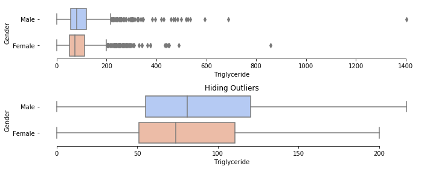

```python
f, axes = plt.subplots(2, 1, figsize=(10, 4))
sns.boxplot(y='Gender', x='Triglyceride', data=df_trig, palette='coolwarm', ax=axes[0])
sns.boxplot(y='Gender', x='Triglyceride', data=df_trig, palette='coolwarm', ax=axes[1], showfliers=False)
sns.despine(trim=True, left=True)
axes[1].set_title("Hiding Outliers")
f.tight_layout()
```

```python
df_trig.groupby('Gender')['Triglyceride'].describe()
```

| Gender | count | mean | std | min | 25% | 50% | 75% | max |
| --- | --- | --- | --- | --- | --- | --- | --- | --- |
| Female | 1242.0 | 87.856683 | 67.503332 | 0.0 | 51.0 | 74.0 | 110.75 | 857.0 |
| Male | 1096.0 | 98.790146 | 85.898399 | 0.0 | 55.0 | 81.0 | 120.25 | 1403.0 |

```python
trig_values_male = np.array(df_trig[df_trig['Gender'] == 'Male']['Triglyceride'])
trig_weights_male = np.array(df_trig[df_trig['Gender'] == 'Male']['Weight Fast'] /
                           df_trig[df_trig['Gender'] == 'Male']['Weight Fast'].mean())

trig_values_female = np.array(df_trig[df_trig['Gender'] == 'Female']['Triglyceride'])
trig_weights_female = np.array(df_trig[df_trig['Gender'] == 'Female']['Weight Fast'] /
                             df_trig[df_trig['Gender'] == 'Female']['Weight Fast'].mean())
```

```python
weighted_estimate(trig_values_female, trig_weights_female, 0.05)
```

```
(93.77461046558993, 90.19344874126992, 97.35577218990994)
```

```python
weighted_estimate(trig_values_male, trig_weights_male, 0.05)
```

```
(106.67718450402494, 102.41275573168058, 110.9416132763693)
```

#### 3.3.2 Income

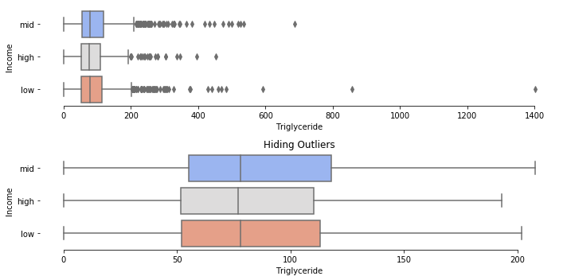

```python
f, axes = plt.subplots(2, 1, figsize=(10, 5))
sns.boxplot(y='Income', x='Triglyceride', data=df_trig, palette='coolwarm', ax=axes[0])
sns.boxplot(y='Income', x='Triglyceride', data=df_trig, palette='coolwarm', ax=axes[1], showfliers=False)
sns.despine(trim=True, left=True)
axes[1].set_title("Hiding Outliers")
f.tight_layout()
```

```python
df_trig.groupby('Income')['Triglyceride'].describe()
```

| Income | count | mean | std | min | 25% | 50% | 75% | max |
| --- | --- | --- | --- | --- | --- | --- | --- | --- |
| high | 408.0 | 87.693627 | 63.854655 | 0.0 | 51.75 | 77.0 | 110.25 | 452.0 |
| low | 792.0 | 94.069444 | 88.720311 | 0.0 | 52.00 | 78.0 | 113.00 | 1403.0 |
| mid | 1021.0 | 95.343781 | 72.917482 | 0.0 | 55.00 | 78.0 | 118.00 | 688.0 |

```python
trig_values_low = np.array(df_trig[df_trig['Income'] == 'low']['Triglyceride'])
trig_weights_low = np.array(df_trig[df_trig['Income'] == 'low']['Weight Fast'] /
                          df_trig[df_trig['Income'] == 'low']['Weight Fast'].mean())

trig_values_mid = np.array(df_trig[df_trig['Income'] == 'mid']['Triglyceride'])
trig_weights_mid = np.array(df_trig[df_trig['Income'] == 'mid']['Weight Fast'] /
                          df_trig[df_trig['Income'] == 'mid']['Weight Fast'].mean())

trig_values_high = np.array(df_trig[df_trig['Income'] == 'high']['Triglyceride'])
trig_weights_high = np.array(df_trig[df_trig['Income'] == 'high']['Weight Fast'] /
                           df_trig[df_trig['Income'] == 'high']['Weight Fast'].mean())
```

```python
weighted_estimate(trig_values_low, trig_weights_low, 0.05)
```

```
(105.39334440455805, 99.62061794069714, 111.16607086841896)
```

```python
weighted_estimate(trig_values_mid, trig_weights_mid, 0.05)
```

```
(97.86760914226276, 93.92223216332383, 101.8129861212017)
```

```python
weighted_estimate(trig_values_high, trig_weights_high, 0.05)
```

```
(99.52404621515471, 94.126219089902, 104.92187334040743)
```

#### 3.3.3 Ethnicity

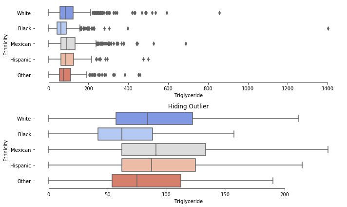

```python
f, axes = plt.subplots(2, 1, figsize=(10, 6))
sns.boxplot(y='Ethnicity', x='Triglyceride', data=df_trig, palette='coolwarm', ax=axes[0])
sns.boxplot(y='Ethnicity', x='Triglyceride', data=df_trig, palette='coolwarm', ax=axes[1], showfliers=False)
sns.despine(trim=True, left=True)
axes[1].set_title("Hiding Outlier")
f.tight_layout()
```

```python
df_trig.groupby('Ethnicity')['Triglyceride'].describe()
```

| Ethnicity | count | mean | std | min | 25% | 50% | 75% | max |
| --- | --- | --- | --- | --- | --- | --- | --- | --- |
| Black | 600.0 | 70.823333 | 72.170468 | 0.0 | 42.00 | 62.0 | 88.0 | 1403.0 |
| Hispanic | 198.0 | 100.005051 | 66.897945 | 0.0 | 62.00 | 87.5 | 124.5 | 500.0 |
| Mexican | 424.0 | 110.514151 | 82.051819 | 0.0 | 62.00 | 91.0 | 133.0 | 688.0 |
| Other | 304.0 | 91.154605 | 68.028574 | 0.0 | 53.75 | 75.0 | 112.0 | 459.0 |
| White | 812.0 | 99.172414 | 79.187099 | 0.0 | 57.00 | 84.0 | 122.0 | 857.0 |

```python
trig_values_black = np.array(df_trig[df_trig['Ethnicity'] == 'Black']['Triglyceride'])
trig_weights_black = np.array(df_trig[df_trig['Ethnicity'] == 'Black']['Weight Fast'] /
                          df_trig[df_trig['Ethnicity'] == 'Black']['Weight Fast'].mean())

trig_values_white = np.array(df_trig[df_trig['Ethnicity'] == 'White']['Triglyceride'])
trig_weights_white = np.array(df_trig[df_trig['Ethnicity'] == 'White']['Weight Fast'] /
                          df_trig[df_trig['Ethnicity'] == 'White']['Weight Fast'].mean())

trig_values_mexican = np.array(df_trig[df_trig['Ethnicity'] == 'Mexican']['Triglyceride'])
trig_weights_mexican = np.array(df_trig[df_trig['Ethnicity'] == 'Mexican']['Weight Fast'] /
                           df_trig[df_trig['Ethnicity'] == 'Mexican']['Weight Fast'].mean())

trig_values_hispanic = np.array(df_trig[df_trig['Ethnicity'] == 'Hispanic']['Triglyceride'])
trig_weights_hispanic = np.array(df_trig[df_trig['Ethnicity'] == 'Hispanic']['Weight Fast'] /
                           df_trig[df_trig['Ethnicity'] == 'Hispanic']['Weight Fast'].mean())

trig_values_other = np.array(df_trig[df_trig['Ethnicity'] == 'Other']['Triglyceride'])
trig_weights_other = np.array(df_trig[df_trig['Ethnicity'] == 'Other']['Weight Fast'] /
                           df_trig[df_trig['Ethnicity'] == 'Other']['Weight Fast'].mean())
```

```python
weighted_estimate(trig_values_black, trig_weights_black, 0.05)
```

```
(75.07059328308932, 71.55001903253421, 78.59116753364444)
```

```python
weighted_estimate(trig_values_white, trig_weights_white, 0.05)
```

```
(105.86121933411441, 100.74662523292787, 110.97581343530095)
```

```python
weighted_estimate(trig_values_mexican, trig_weights_mexican, 0.05)
```

```
(111.29989261594667, 104.67611322845559, 117.92367200343776)
```

```python
weighted_estimate(trig_values_hispanic, trig_weights_hispanic, 0.05)
```

```
(104.45806207209937, 95.52479330708967, 113.39133083710907)
```

```python
weighted_estimate(trig_values_other, trig_weights_other, 0.05)
```

```
(88.57341958647942, 82.58431425635916, 94.56252491659967)
```

### Total Cholesterol Analysis

```python
df_tchol.head()
```

| Index | Age | Gender | Ethnicity | Income | Total Chol | Weight MEC |
| --- | --- | --- | --- | --- | --- | --- |
| 21097.0 | 23.0 | Female | Black | mid | 165.0 | 0.775859 |
| 21107.0 | 20.0 | Male | White | mid | 152.0 | 1.860274 |
| 21130.0 | 20.0 | Female | Black | high | 191.0 | 0.806247 |
| 21171.0 | 20.0 | Female | Black | low | 171.0 | 0.894561 |
| 21175.0 | 18.0 | Female | Black | low | 146.0 | 0.184017 |

```python
df_tchol['Total Chol'].count()
```

```
4370
```

#### 3.3.1 Gender

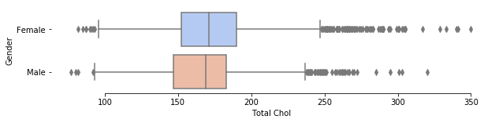

```python
f, ax = plt.subplots(figsize=(10, 2))
sns.boxplot(y='Gender', x='Total Chol', data=df_tchol, palette='coolwarm')
sns.despine(trim=True, left=True)
```

```python
df_tchol.groupby('Gender')['Total Chol'].describe()
```

| Gender | count | mean | std | min | 25% | 50% | 75% | max |
| --- | --- | --- | --- | --- | --- | --- | --- | --- |
| Female | 2304.0 | 174.276422 | 34.814598 | 82.0 | 152.0 | 170.916515 | 190.0 | 350.0 |
| Male | 2066.0 | 167.169553 | 30.496788 | 77.0 | 147.0 | 169.000000 | 183.0 | 320.0 |

```python
tchol_values_male = np.array(df_tchol[df_tchol['Gender'] == 'Male']['Total Chol'])
tchol_weights_male = np.array(df_tchol[df_tchol['Gender'] == 'Male']['Weight MEC'] /
                           df_tchol[df_tchol['Gender'] == 'Male']['Weight MEC'].mean())

tchol_values_female = np.array(df_tchol[df_tchol['Gender'] == 'Female']['Total Chol'])
tchol_weights_female = np.array(df_tchol[df_tchol['Gender'] == 'Female']['Weight MEC'] /
                             df_tchol[df_tchol['Gender'] == 'Female']['Weight MEC'].mean())
```

```python
weighted_estimate(tchol_values_female, tchol_weights_female, 0.05)
```

```
(174.49210547907865, 173.07329414882048, 175.9109168093368)
```

```python
weighted_estimate(tchol_values_male, tchol_weights_male, 0.05)
```

```
(168.79403465076132, 167.44352335895744, 170.1445459425652)
```

#### 3.3.2 Income

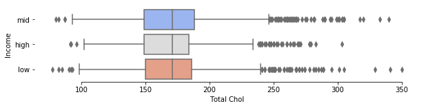

```python
f, ax = plt.subplots(figsize=(10, 2))
sns.boxplot(y='Income', x='Total Chol', data=df_tchol, palette='coolwarm')
sns.despine(trim=True, left=True)
```

```python
df_tchol.groupby('Income')['Total Chol'].describe()
```

| Income | count | mean | std | min | 25% | 50% | 75% | max |
| --- | --- | --- | --- | --- | --- | --- | --- | --- |
| high | 745.0 | 170.657141 | 31.916580 | 91.0 | 149.0 | 170.916515 | 184.0 | 303.0 |
| low | 1521.0 | 170.560688 | 32.710198 | 77.0 | 150.0 | 170.916515 | 186.0 | 350.0 |
| mid | 1902.0 | 171.551816 | 34.052889 | 80.0 | 149.0 | 170.916515 | 188.0 | 340.0 |

```python
tchol_values_low = np.array(df_tchol[df_tchol['Income'] == 'low']['Total Chol'])
tchol_weights_low = np.array(df_tchol[df_tchol['Income'] == 'low']['Weight MEC'] /
                          df_tchol[df_tchol['Income'] == 'low']['Weight MEC'].mean())

tchol_values_mid = np.array(df_tchol[df_tchol['Income'] == 'mid']['Total Chol'])
tchol_weights_mid = np.array(df_tchol[df_tchol['Income'] == 'mid']['Weight MEC'] /
                          df_tchol[df_tchol['Income'] == 'mid']['Weight MEC'].mean())

tchol_values_high = np.array(df_tchol[df_tchol['Income'] == 'high']['Total Chol'])
tchol_weights_high = np.array(df_tchol[df_tchol['Income'] == 'high']['Weight MEC'] /
                           df_tchol[df_tchol['Income'] == 'high']['Weight MEC'].mean())
```

```python
weighted_estimate(tchol_values_low, tchol_weights_low, 0.05)
```

```
(171.23113467737096, 169.57906516251504, 172.88320419222688)
```

```python
weighted_estimate(tchol_values_mid, tchol_weights_mid, 0.05)
```

```
(172.04877771718307, 170.52165305052532, 173.57590238384083)
```

```python
weighted_estimate(tchol_values_high, tchol_weights_high, 0.05)
```

```
(171.64714382381223, 169.3226212533826, 173.97166639424185)
```

#### 3.3.3 Ethnicity

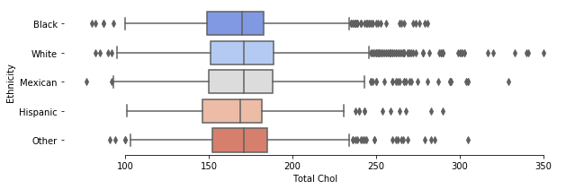

```python
f, ax = plt.subplots(figsize=(10, 3))
sns.boxplot(y='Ethnicity', x='Total Chol', data=df_tchol, palette='coolwarm')
sns.despine(trim=True, left=True)
```

```python
df_tchol.groupby('Ethnicity')['Total Chol'].describe()
```

| Ethnicity | count | mean | std | min | 25% | 50% | 75% | max |
| --- | --- | --- | --- | --- | --- | --- | --- | --- |
| Black | 1137.0 | 168.453076 | 30.636016 | 80.0 | 149.0 | 170.000000 | 183.0 | 281.0 |
| Hispanic | 333.0 | 167.029763 | 30.427093 | 101.0 | 146.0 | 169.000000 | 182.0 | 290.0 |
| Mexican | 771.0 | 171.519657 | 34.134899 | 77.0 | 150.0 | 170.916515 | 188.0 | 329.0 |
| Other | 519.0 | 171.243880 | 31.024265 | 91.0 | 152.0 | 170.916515 | 185.0 | 305.0 |
| White | 1610.0 | 173.065767 | 35.060863 | 82.0 | 151.0 | 170.916515 | 189.0 | 350.0 |

```python
tchol_values_black = np.array(df_tchol[df_tchol['Ethnicity'] == 'Black']['Total Chol'])
tchol_weights_black = np.array(df_tchol[df_tchol['Ethnicity'] == 'Black']['Weight MEC'] /
                          df_tchol[df_tchol['Ethnicity'] == 'Black']['Weight MEC'].mean())

tchol_values_white = np.array(df_tchol[df_tchol['Ethnicity'] == 'White']['Total Chol'])
tchol_weights_white = np.array(df_tchol[df_tchol['Ethnicity'] == 'White']['Weight MEC'] /
                          df_tchol[df_tchol['Ethnicity'] == 'White']['Weight MEC'].mean())

tchol_values_mexican = np.array(df_tchol[df_tchol['Ethnicity'] == 'Mexican']['Total Chol'])
tchol_weights_mexican = np.array(df_tchol[df_tchol['Ethnicity'] == 'Mexican']['Weight MEC'] /
                           df_tchol[df_tchol['Ethnicity'] == 'Mexican']['Weight MEC'].mean())

tchol_values_hispanic = np.array(df_tchol[df_tchol['Ethnicity'] == 'Hispanic']['Total Chol'])
tchol_weights_hispanic = np.array(df_tchol[df_tchol['Ethnicity'] == 'Hispanic']['Weight MEC'] /
                           df_tchol[df_tchol['Ethnicity'] == 'Hispanic']['Weight MEC'].mean())

tchol_values_other = np.array(df_tchol[df_tchol['Ethnicity'] == 'Other']['Total Chol'])
tchol_weights_other = np.array(df_tchol[df_tchol['Ethnicity'] == 'Other']['Weight MEC'] /
                           df_tchol[df_tchol['Ethnicity'] == 'Other']['Weight MEC'].mean())
```

```python
weighted_estimate(tchol_values_black, tchol_weights_black, 0.05)
```

```
(168.79054389349733, 166.99352315362904, 170.58756463336562)
```

```python
weighted_estimate(tchol_values_white, tchol_weights_white, 0.05)
```

```
(172.72829722569105, 171.07199210088245, 174.38460235049965)
```

```python
weighted_estimate(tchol_values_mexican, tchol_weights_mexican, 0.05)
```

```
(170.35639821328928, 168.08613341910083, 172.62666300747773)
```

```python
weighted_estimate(tchol_values_hispanic, tchol_weights_hispanic, 0.05)
```

```
(167.85462846789065, 164.3232148624996, 171.3860420732817)
```

```python
weighted_estimate(tchol_values_other, tchol_weights_other, 0.05)
```

```
(172.7579045095308, 169.9165864098209, 175.59922260924068)
```

## 3 Results

The results can be summarized into the following table:

*Average 2003-2016 NHANES Lipid Values by Race, Gender, and Income*

[output not shown]